# Ensino em Bioinformática

Heron O.H.

05 September, 2025

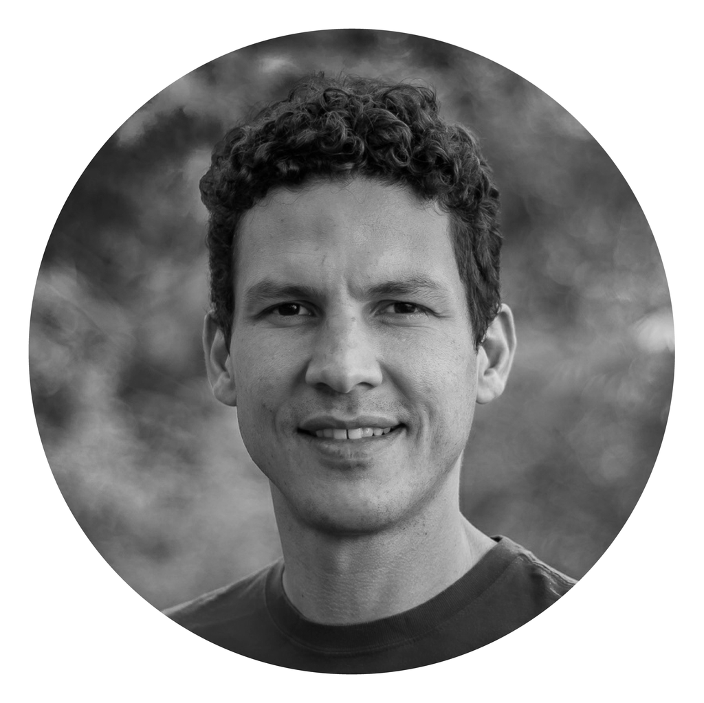

**Bem vind*!**

**Neste canal iremos desbravar o universo da bioinformática.**

Aqui disponibilizarei os roteiros de aulas práticas produzidos para a disciplina *Bioinformática e Genômica*, da PUC Minas. Estes roteiros tem como objetivo facilitar o primeiro contato com a bioinformática, através de explicações e exercícios.

### Aulas práticas

#### R (RStudio)

- A **linguagem R** e o **RStudio**  
  `/home/heron/prjcts/bioinfo/aulas/aulas_R/Pratica_1-o_R_e_o_RStudio.Rmd`
- Visualização de dados do SUS  
  `/home/heron/prjcts/bioinfo/aulas/aulas_R/Pratica_2-Visualizacao_de_dados_do_SUS.Rmd`
- Prática 2 — Visualização de dados do SUS  
  `/home/heron/prjcts/bioinfo/aulas/aulas_R/Pratica_2-Visualizacao_de_dados_do_SUS_quarto_clean.qmd`
- Prática 3 — Sequências biológicas: Arquivos fasta e fastq  
  `/home/heron/prjcts/bioinfo/aulas/aulas_R/Pratica_3-Arquivos_fasta_e_fastq.qmd`

#### bash (WSL/Ubuntu)

- Dicionário de comandos em *bash*  
  `/home/heron/prjcts/bioinfo/aulas/aulas_bash/Dicionario_de_comandos.Rmd`
- Práticas em Bioinfo I  
  `/home/heron/prjcts/bioinfo/aulas/aulas_bash/Pratica_1-Bioinfo.Rmd`
- Práticas em Bioinfo II  
  `/home/heron/prjcts/bioinfo/aulas/aulas_bash/Pratica_2-Bioinfo.Rmd`
- Práticas em Bioinfo III  
  `/home/heron/prjcts/bioinfo/aulas/aulas_bash/Pratica_3-Bioinfo.Rmd`
- Práticas em Bioinfo IV  
  `/home/heron/prjcts/bioinfo/aulas/aulas_bash/Pratica_4-Bioinfo.Rmd`
- Práticas em Bioinfo V  
  `/home/heron/prjcts/bioinfo/aulas/aulas_bash/Pratica_5-Bioinfo.Rmd`